# 607_assignment_5

Eddie Xu

2023-02-24

```r
library(tidyverse)
```

## Data 607 Assignment 5

Given a messy data, the goal is to tidy and transform data to suit the need for data analysis and to answer the question: Which airline provide a better service in term of flight quality?

## Read CSV

```r
readfile <- data.frame(read.csv("https://raw.githubusercontent.com/eddiexunyc/607_assignment_5/main/tidy%20data.csv", header =TRUE))

head(readfile)
```

```
##       ï..       X Los.Angeles Phoenix San.Diego San.Francisco Seattle
## 1  ALASKA on time         497     221       212           503    1841
## 2         delayed          62      12        20           102     305
## 3                          NA      NA        NA            NA      NA
## 4 AM WEST on time         694    4840       383           320     301
## 5         delayed         117     415        65           129      61
```

## Data Cleaning

Since the csv file is untidy and does not follow the principle of tidy data where:

1. Every column is a variable
2. Every row is an observation
3. Every cell is a single value

The data will be cleansed to reflect that.

```r
##split the data based on the row number
alaska_df <- readfile[1:2,]
amwest_df <- readfile[4:5,]
```

After splitting the data by airline, each airline data will be cleaned up.

```r
##rename the column
colnames(alaska_df) <- c("Airline", "Arrival Status", "Los Angeles", "Phoenix", "San Diego","San Francisco", "Seattle")

##fill in the null value with new value for Alaska
alaska_df$Airline[alaska_df$Airline == ""] <-c("ALASKA")

##pivot longer the city and value
alaska_tidy_data <- alaska_df %>%
  pivot_longer(cols = c("Los Angeles", "Phoenix", "San Diego","San Francisco", "Seattle"), names_to = "City", values_to = "Count")

knitr::kable(alaska_tidy_data)
```

| Airline | Arrival Status | City | Count |
| --- | --- | --- | --- |
| ALASKA | on time | Los Angeles | 497 |
| ALASKA | on time | Phoenix | 221 |
| ALASKA | on time | San Diego | 212 |
| ALASKA | on time | San Francisco | 503 |
| ALASKA | on time | Seattle | 1841 |
| ALASKA | delayed | Los Angeles | 62 |
| ALASKA | delayed | Phoenix | 12 |
| ALASKA | delayed | San Diego | 20 |
| ALASKA | delayed | San Francisco | 102 |
| ALASKA | delayed | Seattle | 305 |

```r
##rename the column
colnames(amwest_df) <- c("Airline", "Arrival Status", "Los Angeles", "Phoenix", "San Diego","San Francisco", "Seattle")

##fill in the null value with new value
amwest_df$Airline[amwest_df$Airline == ""] <-c("AM WEST")

##pivot longer the city and value
amwest_tidy_data <- amwest_df %>%
  pivot_longer(cols = c("Los Angeles", "Phoenix", "San Diego","San Francisco", "Seattle"), names_to = "City", values_to = "Count")

knitr::kable(amwest_tidy_data)
```

| Airline | Arrival Status | City | Count |
| --- | --- | --- | --- |
| AM WEST | on time | Los Angeles | 694 |
| AM WEST | on time | Phoenix | 4840 |
| AM WEST | on time | San Diego | 383 |
| AM WEST | on time | San Francisco | 320 |
| AM WEST | on time | Seattle | 301 |
| AM WEST | delayed | Los Angeles | 117 |
| AM WEST | delayed | Phoenix | 415 |
| AM WEST | delayed | San Diego | 65 |
| AM WEST | delayed | San Francisco | 129 |
| AM WEST | delayed | Seattle | 61 |

```r
##combine both amwest and alaska dataframe together
airline_tidy_data <- rbind(alaska_tidy_data, amwest_tidy_data)

knitr::kable(airline_tidy_data)
```

| Airline | Arrival Status | City | Count |
| --- | --- | --- | --- |
| ALASKA | on time | Los Angeles | 497 |
| ALASKA | on time | Phoenix | 221 |
| ALASKA | on time | San Diego | 212 |
| ALASKA | on time | San Francisco | 503 |
| ALASKA | on time | Seattle | 1841 |
| ALASKA | delayed | Los Angeles | 62 |
| ALASKA | delayed | Phoenix | 12 |
| ALASKA | delayed | San Diego | 20 |
| ALASKA | delayed | San Francisco | 102 |
| ALASKA | delayed | Seattle | 305 |
| AM WEST | on time | Los Angeles | 694 |
| AM WEST | on time | Phoenix | 4840 |
| AM WEST | on time | San Diego | 383 |
| AM WEST | on time | San Francisco | 320 |
| AM WEST | on time | Seattle | 301 |
| AM WEST | delayed | Los Angeles | 117 |
| AM WEST | delayed | Phoenix | 415 |
| AM WEST | delayed | San Diego | 65 |
| AM WEST | delayed | San Francisco | 129 |
| AM WEST | delayed | Seattle | 61 |

## Data Analysis

Now that the data is in a tidy format, the data analysis can be done on the airline data.

Let’s see the arrival status in a bar graph

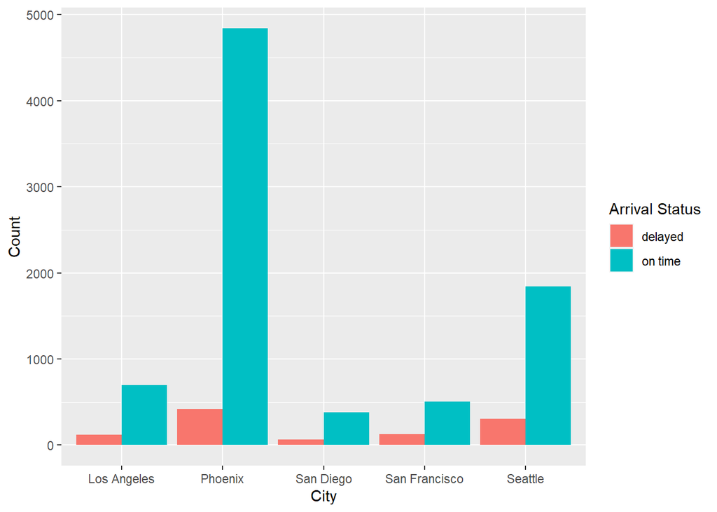

```r
#bar graph based on the arrival status by city.
ggplot(airline_tidy_data, aes(x = City, y= Count, fill = `Arrival Status`)) +
  geom_bar(stat = "identity", position = "dodge")
```

As shown, Phoenix have the highest count for “On-time” arrival status, compared to other cities.

```r
#summarize the data
airline_summary <- airline_tidy_data %>% group_by(`Airline`, `Arrival Status`) %>%
  summarize_at('Count', mean)

head(airline_summary)
```

```
## # A tibble: 4 x 3
## # Groups:   Airline [2]
##   Airline `Arrival Status` Count
##   <chr>   <chr>            <dbl>
## 1 ALASKA  delayed           100.
## 2 ALASKA  on time           655.
## 3 AM WEST delayed           157.
## 4 AM WEST on time          1308.
```

Comparison from a bar graph

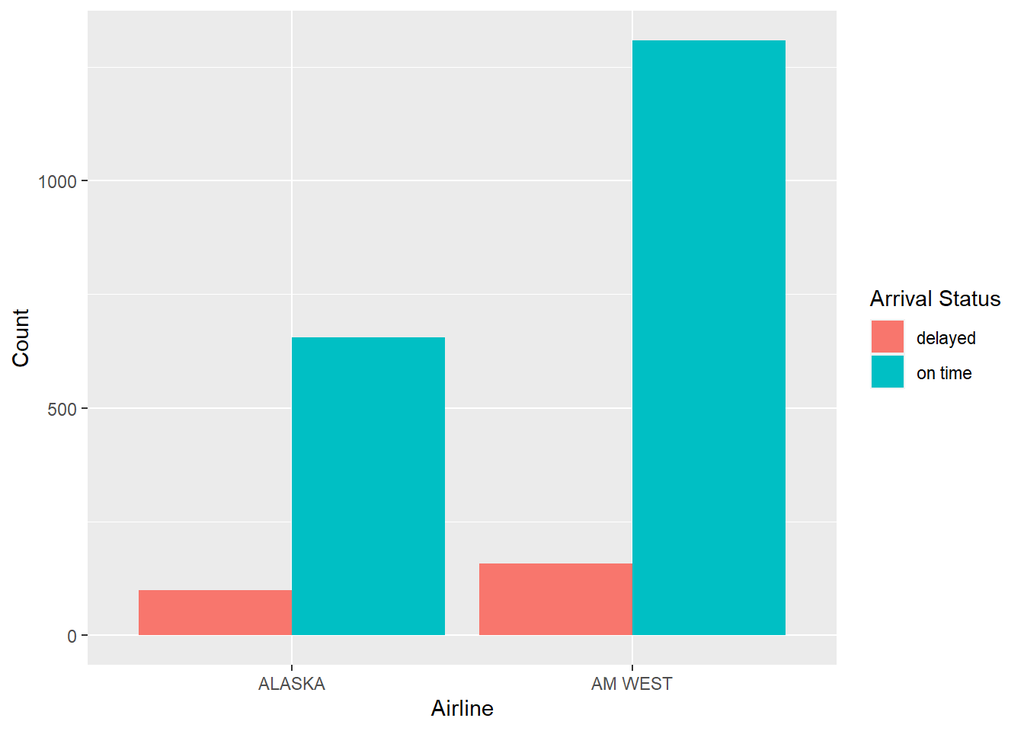

```r
ggplot(airline_summary, aes(x = `Airline`, y = `Count`, fill = `Arrival Status`)) +
  geom_bar(stat = "identity", position = "dodge")
```

Based on the graph, it shows that the AM WEST airline have more “on-time” arrival status than the ALASKA airline. Of course, this is not a definitive proof that the AM WEST airline is better than ALASKA airline.

To see how well each airline performs, the ratio of “on-time” and “delayed” will be calculated to determine their performance in every cities.

```r
#change the data format to include "on-time' and "delayed" column through pivot wider
airline_tidy_data2 <- airline_tidy_data %>%
  pivot_wider(names_from = "Arrival Status", values_from = "Count")

airline_tidy_data2["Arrival Status Ratio"] <- round(airline_tidy_data2$`on time`/airline_tidy_data2$delayed, 2)

knitr::kable(airline_tidy_data2)
```

| Airline | City | on time | delayed | Arrival Status Ratio |
| --- | --- | --- | --- | --- |
| ALASKA | Los Angeles | 497 | 62 | 8.02 |
| ALASKA | Phoenix | 221 | 12 | 18.42 |
| ALASKA | San Diego | 212 | 20 | 10.60 |
| ALASKA | San Francisco | 503 | 102 | 4.93 |
| ALASKA | Seattle | 1841 | 305 | 6.04 |
| AM WEST | Los Angeles | 694 | 117 | 5.93 |
| AM WEST | Phoenix | 4840 | 415 | 11.66 |
| AM WEST | San Diego | 383 | 65 | 5.89 |
| AM WEST | San Francisco | 320 | 129 | 2.48 |
| AM WEST | Seattle | 301 | 61 | 4.93 |

Chart view of the ratio

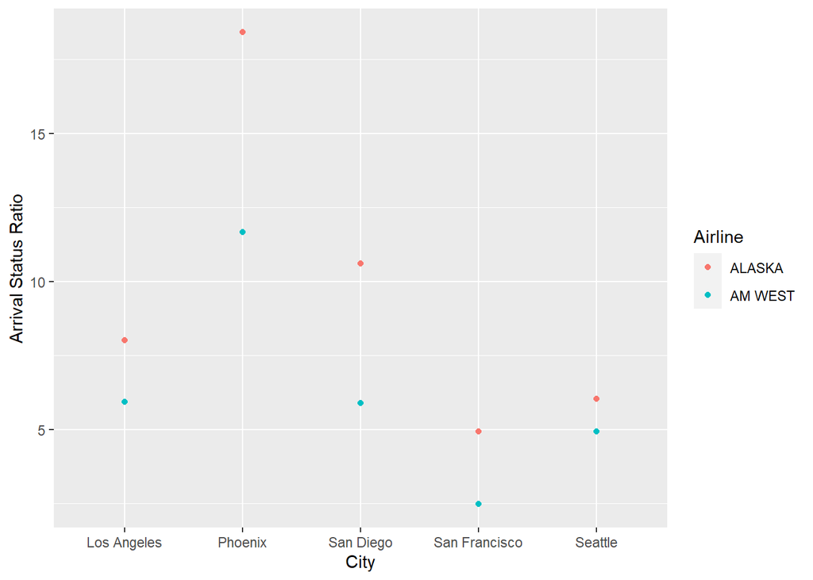

```r
ggplot(airline_tidy_data2, aes(x = `City`, y = `Arrival Status Ratio`, color = `Airline`)) +
  geom_point()
```

## Conclusion

In conclusion, despite the AM WEST airline have more “on-time” arrival flight than the ALASKA airline, the latter airline performs better due to on-time/delayed ratio.